# Paquete_ggvenn

2023-04-22

# ggvenn:

En RStudio ggvenn es un paquete de visualización de datos que se utiliza para crear diagramas de Venn interactivos en R. Este tipo de gráficos es útil para comparar y contrastar conjuntos de datos. Con ggvenn, puedes mostrar varios conjuntos de datos y resaltar las intersecciones entre ellos.

Para utilizar ggvenn, se debe instalar y cargar el paquete en la sesión de R. Para hacerlo, se deben ejecutar los siguientes comandos:

```r
library(ggplot2)
library(ggvenn)
```

Una vez que se haya cargado el paquete, se puede comenzar a crear los diagramas de Venn.

#### Ejemplo básico:

```r
# Crear un diagrama de Venn con dos conjuntos de datos
a <- list (`Positivismo` = sort(sample(1:10000000, 1000000)),
           `Constructivismo` = sort(sample(1:10000000, 1000000)))
```

**Significado de cada argumento:**

- **`a <- list(`**: Esto crea una lista en R y la asigna a la variable “a”.
- **`Positivismo`** y **`Constructivismo`**: Estos son los nombres de los dos conjuntos de datos que se utilizarán para crear el diagrama de Venn. Estos nombres se incluyen dentro de comillas invertidas (`) para indicar que son cadenas de texto.
- **`sort(sample(1:10000000, 1000000))`**: Este comando genera un conjunto de datos aleatorios de un millón de números enteros ordenados de forma ascendente utilizando la función **`sample`** y la función **`sort`** en R. Este conjunto de datos se asigna al conjunto de datos “Positivismo”.

En este ejemplo, estamos comparando dos conjuntos de datos (paradígmas) nombrados bajo “a”, que contiene valores del 1:10000000.

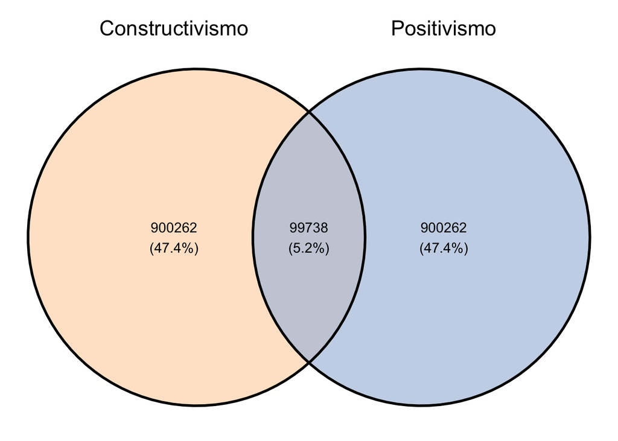

```r
# Crear el diagrama de Venn
ggvenn(a, c("Constructivismo", "Positivismo"),
       fill_color = c("peachpuff", "lightsteelblue"),
       fill_alpha = (.7))
```

**Significado de cada argumento:**

- **`ggvenn(a, c("Constructivismo", "Positivismo"))`**: Este comando llama a la función **`ggvenn`** y le pasa dos argumentos;
  - La lista **`a`** que contiene los conjuntos de datos “Positivismo” y “Constructivismo”, y el vector **`"Constructivismo", "Positivismo"`** que indica los nombres de los conjuntos que se van a graficar.